## 2024 CAV Short Course

# Machine Learning & AI in Acoustics and Vibration

## Session 1, Part I: Introduction, Basic Concepts

## Instructor: Daning Huang

$$ \newcommand{\norm}[1]{\left\lVert{#1}\right\rVert} \newcommand{\R}{\mathbb{R}} \renewcommand{\vec}[1]{\mathbf{#1}} \newcommand{\X}{\mathcal{X}} \newcommand{\D}{\mathcal{D}} \newcommand{\cL}{\mathcal{L}} $$

## Outline

- Definitions
- Categories of machine learning
- Model selection
- Model biases

# Definitions

Consider a generic model $$ \hat{y} = f(x,\theta) $$ where

- $f$ model
- $x$ input
- $\theta$ parameter
- $\hat{y}$ predicted output

Given a dataset of $N$ samples $$ \D = \{(x_i, y_i)\}_{i=1}^N $$ we minimize a loss $$ \min_\theta \cL(y,\hat{y}) $$

The simplest model is perhaps linear regression. For example, $$ f(x,\theta) = \theta_0 + \theta_1 x_1 + \cdots + \theta_m x_m \equiv \theta^T\phi(x) $$ with a squared loss $$ \cL(y,\hat{y}) = \sum_{i=1}^N \norm{y_i-\theta^T\phi(x_i)}^2 $$ For this one we have closed-formed solution.

Challenge comes in when we go for more complex models, e.g., "deep" models. Possible complexities:

- Input/Output, $x,y$
  - Images, Audio, Graph, text
  - Missing data
  - Data noise
  - etc.
- Model form, $f$
  - Multi-layer perceptron
  - Differential equations
  - Embedded optimization
  - etc.
- Loss, $\cL$
  - Parametric sparsity
  - Physics-informed losses
  - Lipschitz constant
  - etc.
- Difficulties in learning deep models
  - Easily overfit (The number of parameters is large)
  - Hard to optimize (highly non-convex optimization)
  - Computationally expensive (many matrix multiplications)
- Recent Advances
  - Large-scale dataset (e.g., 1M images in ImageNet, PB text for ChatGPT)
  - Better regularization (e.g., Dropout, spectral)
  - Better optimization (e.g., Adam family)
  - Better hardware (GPU/TPU for matrix computation)

# Basic Concepts

## Categories of machine learning models

Zoo of models: Supervised, unsupervised, semi-supervised, etc.

## Supervised Learning

$$ \hat{y} = f(x,\theta) $$

Two major categories:

- **Regression**: $\hat{y}$ is continuous
- **Classification**: $\hat{y}$ is discrete - True/False, category indices

## Unsupervised Learning

$$ \hat{y} = f(x,\theta) $$

The output $\hat{y}$ is not given.

Typical examples:

- **Dimension reduction**: $\hat{y}=x$, and we let $$ z=f_1(x,\theta_1),\quad x=f_2(z,\theta_2),\quad \text{dim}(z)\ll\text{dim}(x) $$
- **Generative model**: e.g., $$ x=f(z,\theta),\quad z\sim \mathcal{N}(0,1) $$
  - At the core of many AI artists
- **Cluster**: $\hat{y}$ as unknown categories
  - Special case: Anomaly detection

## Semi-supervised Learning

The main example:

- **Reinforcement learning**: State $s$, Action $a$, Reward $r$
  - Agent(s) explore in an environment and gain experience, $(s_i,a_i,r_i)$
  - Iteratively update the Policy $a=\pi(s)$ as the Agent(s) explore

# Basic Concepts

## Model selection: Bias-variance trade-off

Understanding the error of a machine learning model

### Bias and Variance Formulae

- Consider $y(x) = f^*(x) + \epsilon$
  - $f^*$ is the **true model**
  - $\epsilon$ is some $0$-mean noise with variance $\sigma^2$
- A model receives one dataset $S$ and outputs $\hat f$ as prediction of $y$. The error is:

$$\mathbb{E}[(y - \hat{f})^2] = \underbrace{{\sigma^2}}_\text{irreducible error} + \underbrace{{\text{Var}[\hat{f}]}}_\text{Variance} + \underbrace{(f - \mathbb{E}[\hat{f}])^2}_{\text{Bias}^2}$$

where expectation is taken w.r.t. *all possible* datasets, $\mathbb{E}[f(S)]=\mathbb{E}_S[f(S)]=\int f(S)p(S)dS$.

- Break error into two terms relating to $\mathbb{E}[\hat f]$ the "average" estimate over random datasets $S$.
  - Irreducible error: Minimum possible error - determined by measurement noise
  - Bias: Fitting capability - "complexity" of model
  - Variance: Generalization capability - Model sensitivity to changes in dataset, (overfitting)

### An example to explain Bias/Variance and illustrate the tradeoff

- Consider estimating a sinusoidal function.

(Example that follows is inspired by Yaser Abu-Mostafa's CS 156 Lecture titled "Bias-Variance Tradeoff"

## Let's a simple polynomial fitting problem

- Here we generate some samples $x,y$, with $y = \sin(\pi x)$
- We then fit a degree-$0$ polynomial (i.e. a constant function) to the samples

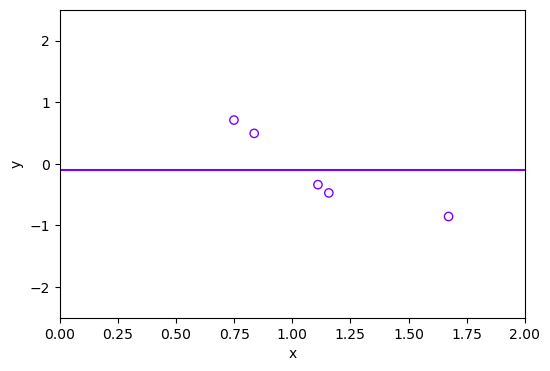

```python
# polyfit_sin() generates 5 samples of the form (x,y) where y=sin(pi*x)
# then it tries to fit a degree=0 polynomial (i.e. a constant func.) to the data
# Ignore return values for now, we will return to these later
_, _, _, _ = polyfit_sin(degree=0, iterations=1, num_points=5, show=True)
```

## We can do this over many datasets

- Let's sample a number of datasets
- How does the fitted polynomial change for different datasets?

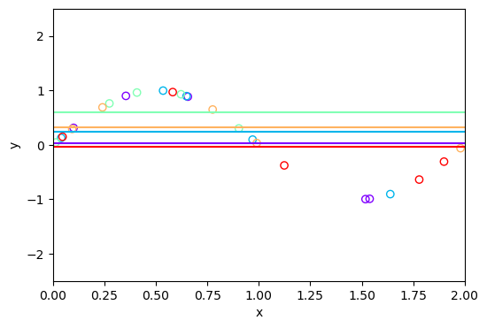

```python
# Estimate two points of sin(pi * x) with a constant 5 times
_, _, _, _ = polyfit_sin(degree=0, iterations=5)
```

## What about over lots more datasets?

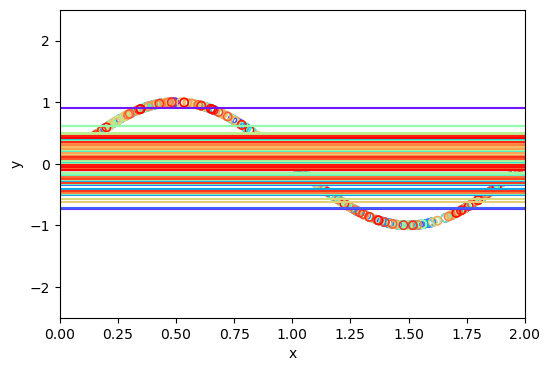

```python
# Estimate two points of sin(pi * x) with a constant 100 times
_, _, _, _ = polyfit_sin(degree=0, iterations=100)
```

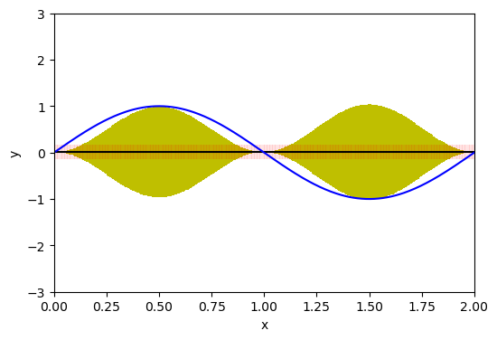

```python
MSE, errs, mean_coeffs, coeffs_list = polyfit_sin(degree=0, iterations=100, num_points=3, show=False)
biases, variances = calculate_bias_variance(coeffs_list,RANGEXS,TRUEYS)
plot_bias_and_variance(biases,variances,RANGEXS,TRUEYS,np.polyval(np.poly1d(mean_coeffs), RANGEXS))
```

- Decomposition: $\mathbb{E}[(y - \hat{f})^2] = \underbrace{{\sigma^2}}_\text{irreducible error} + \underbrace{{\text{Var}[\hat{f}]}}_\text{Variance} + \underbrace{(f - \mathbb{E}[\hat{f}])^2}_{\text{Bias}^2}$
- Blue curve: true $f$
- Black curve: $\hat f$, average predicted values of $y$
- Yellow is error due to **Bias**, Red/Pink is error due to **Variance**

## Bias vs. Variance

- We can calculate how much error we suffered due to bias and due to variance

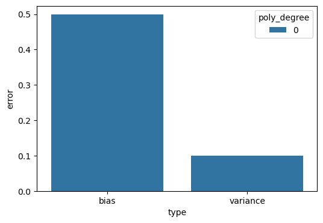

```python
poly_degree, results_list = 0, []
MSE, errs, mean_coeffs, coeffs_list = polyfit_sin(poly_degree, 500,num_points = 5,show=False)
biases, variances = calculate_bias_variance(coeffs_list,RANGEXS,TRUEYS)
sns.barplot(x='type', y='error',hue='poly_degree', data=pd.DataFrame([{'error':np.mean(biases), 'type':'bias','poly_degree':0},
    {'error':np.mean(variances), 'type':'variance','poly_degree':0}]))
```

## Let's now fit degree=3 polynomials

- Let's sample a dataset of 5 points and fit a cubic poly

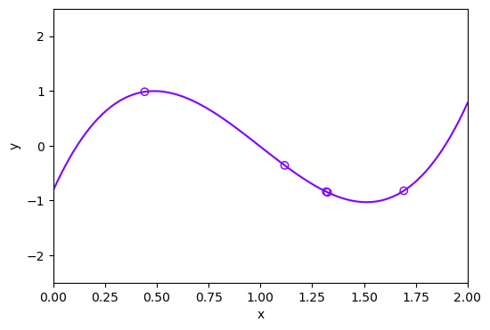

```python
MSE, _, _, _ = polyfit_sin(degree=3, iterations=1)
```

## Let's now fit degree=3 polynomials

- What does this look like over 5 different datasets?

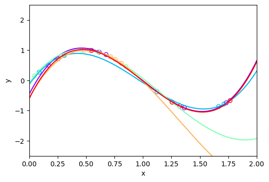

```python
_, _, _, _ = polyfit_sin(degree=3,iterations=5,num_points=5,show=True)
```

## Let's now fit degree=3 polynomials

- What does this look like over 50 different datasets?

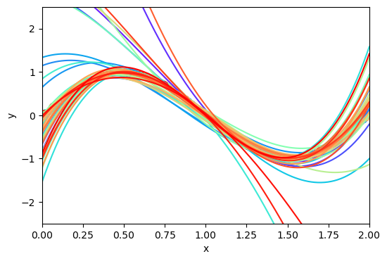

```python
# Estimate two points of sin(pi * x) with a line 50 times
_, _, _, _ = polyfit_sin(degree=3, iterations=50)
```

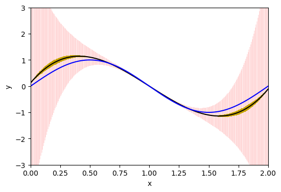

```python
MSE, errs, mean_coeffs, coeffs_list = polyfit_sin(3,500,show=False)
biases, variances = calculate_bias_variance(coeffs_list,RANGEXS,TRUEYS)
plot_bias_and_variance(biases,variances,RANGEXS,TRUEYS,np.polyval(np.poly1d(mean_coeffs), RANGEXS))
```

$$\mathbb{E}[(y - \hat{f})^2] = \underbrace{{\sigma^2}}_\text{irreducible error} + \underbrace{{\text{Var}[\hat{f}]}}_\text{Variance} + \underbrace{(f - \mathbb{E}[\hat{f}])^2}_{\text{Bias}^2}$$

- Blue curve: true $f$
- Black curve: $\mathbb{E}[\hat f]$, average prediction of $y$
- Yellow is error due to **Bias**, Red/Pink is error due to **Variance**

## Bias and Variance for different degree sizes

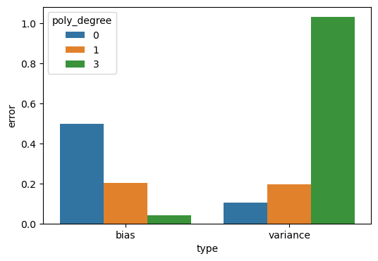

```python
sns.barplot(x='type', y='error',hue='poly_degree',data=pd.DataFrame(results_list))
```

- High degree polys have lower bias but much greater variance!
- **Bias-Variance Dilemma**

[figure not shown]

## Methods for Model Selection

### Cross-Validation

For a model $M(\alpha)$ with complexity parameter $\alpha$

- Split the dataset into K-fold
- For i=1,...,K
  - Remove the *i*th fold and train a model
  - Compute the error $E_i$ on the *i*th fold
- Average all the errors $E_1$,...,$E_K$ to obtain the estimated error of $M(\alpha)$

Repeat for different $\alpha$'s and find the one with minimum error

[figure not shown]

## Deep Double Descent in Over-parametrized Case

AKA in deep learning: https://openai.com/blog/deep-double-descent/

[figure not shown]

# Basic Concepts

## Observational, inductive, learning, and physics biases

We practically can design and train **any** parametrized model of **any** architecture.

But we would want the family of models to be **compatible with** the problem at hand.

For example, the model should

- Capture *temporal correlation* for *time series*.
- Generate *localized features* for *object detection* in images.
- Preserve *symmetry* of the original problem. (e.g., if we fit an odd function, the NN should be odd too)
- Satisfy any physics-based relations that are already *known*.
- etc.

## Biases

There are (at least) four types of biases: **observational**, **inductive**, **learning**, and **physics**.

Refs: [Battaglia2018](https://arxiv.org/abs/1806.01261), [Karniadakis2021](https://www.nature.com/articles/s42254-021-00314-5.)

To make it more tangible, suppose we want to fit a simple model for a nonlinear spring $$ F = k_1 x + k_2 x^3 $$ given data of $(x_i,F_i)$.

- Physical knowledge tells us that the model should be an odd function.

### Observation Bias

- No special structure on the model.
- Manipulate the data so that it satisfies our knowledge
  - For a data point $(x_i,F_i)$, make sure $(-x_i,-F_i)$ is also a data point.
  - Or, sample strategically to achieve the same effect
- Within the range of (augmented) data, the learned model is *approximately* an odd function.

> Cons: Higher training cost for larger dataset; only approximation

### Inductive Bias

- Place structure on the model to enforce known knowledge.
  - Given any model $\hat{f}(x)$, define $f(x) = \hat{f}(x)-\hat{f}(-x)$ as our final model.
  - $f(x)$ is always odd.
- One more example: Say we want the output to be a $3\times 3$ rotation matrix $R$.
  - Need $|R|=1$, so simply outputing a $3\times 3$ array would not work.
  - Instead we learn a vector $x=[x_1,x_2,x_3]$, and for *any* $x$, $\exp(\hat{x})$ is a rotation matrix $$ \hat{x} = \begin{bmatrix} 0 & -x_3 & x_2 \\ x_3 & 0 & -x_1 \\ -x_2 & x_1 & 0 \end{bmatrix} $$

### Learning Bias

- No special structure on the model or data.
- Design special losses to enforce the model form.
  - Add a penalty $L(x) = f(x)+f(-x)$
  - $f(x)$ gets penalized when it is not odd
- One more example: "physics-informed" neural network
  - Want solution to a PDE $u_{xx}+u_{yy}=0$.
  - Define a network $u^*(x,y)$ and drive a loss $||u^*_{xx}+u^*_{yy}||$ to zero.
  - (Technically we also need losses on boundary conditions)
- More on these models in this module.

### Physics Bias

- Embed physics-based model into the model.
  - Suppose we know a baseline relation $F\approx k^* x$, $k^*$ known
  - Define model as $F=k^* x + \hat{f}(x)$, and learn $\hat{f}$ instead of the entire $F$.
- One more example: Constitutive relations for elasticity
  - $\nabla\cdot \sigma(\epsilon)=F$, $F$ force, $\sigma$ stress, $\epsilon$ strain
  - We keep the equation in the model and just learn $\sigma(\epsilon)$